# Data Handling: Import, Cleaning and Visualisation

02/12/2021

## Updates

## Reminder

- Send questions for the Q&A session (last lecture)
- *ulrich.matter@unisg.ch*

## Reminder: Guest Lecture by Corina Grünenfelder

*9 December 2021, “Data Science in Insurance”*

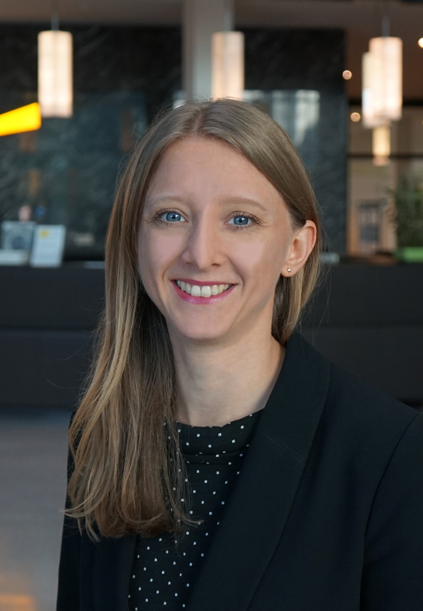

*Corina Grünenfelder*, M.Sc. Mathematics, Actuary SSA  
Director, EY

## Recap: Data Preparation

[figure not shown]

## The dataset is imported, now what?

- In practice: still a long way to go.
- Parsable, but messy data: Inconsistencies, data types, missing observations, wide format.
- *Goal* of data preparation: Dataset is ready for analysis.
- *Key conditions*:
  1. Data values are consistent/clean within each variable.
  2. Variables are of proper data types.
  3. Dataset is in ‘tidy’ (in long format)!